# Causal ML for Treatment Outcomes: Smoking, BMI, and Diabetes

Illustrating Feuerriegel et al. (2024) *Nature Medicine* with the G-Formula and Causal Mediation

Author

Arda

Published

July 2, 2026

## 1 Motivation

Feuerriegel et al. (2024) argue that standard ML pipelines fail when estimating treatment effects because they ignore the **causal structure** linking treatment, mediators, and outcomes. Their canonical example:

> *“Consider a patient with a high body mass index whose doctor recommends quitting smoking, and for whom the diabetes risk should be predicted. Literature from traditional ML would suggest using both the body mass index and smoking behavior to predict the diabetes risk under a smoking versus no-smoking scenario; however, this approach would ignore that stopping smoking would also change a patient’s body mass index.”*

This document implements a principled causal analysis of exactly that example using three approaches:

| Approach | Description | Validity |
| --- | --- | --- |
| **(A) Naïve ML** | Logistic regression on post-treatment BMI | ❌ Biased (conditions on mediator) |
| **(B) Causal mediation** | Decomposes total effect into direct + BMI-mediated (Imai, Keele, and Tingley 2010) | ✅ Correct decomposition |
| **(C) G-formula / SCM** | Intervenes `do(quit=1)`, propagates through BMI | ✅ Correct counterfactual ATE |

### 1.1 Empirical basis

The synthetic cohort is calibrated to three published sources:

- Hu et al. (2018) (NHS / NHS-II / HPFS cohorts, *NEJM*): post-cessation weight gain explained ~68% of the transient type 2 diabetes (T2D) spike; HR ≈ 1.91 for quitters with ≥10 kg gain.
- **Kangbuk Samsung Health Study** (2024): mean BMI 25.68 ± 3.53 (T2D) vs 23.18 ± 3.28 (non-T2D); current smokers HR ≈ 1.29.
- Bush et al. (2016): post-cessation BMI increase ≈ 0.9 kg/m² within 3 years; magnitude varies with baseline BMI.

## 2 Packages

```r
pkgs <- c("ggplot2", "mediation")
for (p in pkgs) if (!requireNamespace(p, quietly = TRUE)) install.packages(p)
library(ggplot2)
library(mediation)
```

## 3 Causal DAG

The assumed structural equation model:

| Quantity | Expected (probability scale) |
| --- | --- |
| ADE — direct protective effect of quitting | ≈ −0.010 to −0.015 |
| ACME — harm mediated via BMI gain | ≈ +0.005 to +0.010 |
| ATE — net total effect (ADE + ACME) | ≈ −0.004 to −0.008 |

The key path ignored by naïve ML is **Quit → ΔBMI → T2D**.

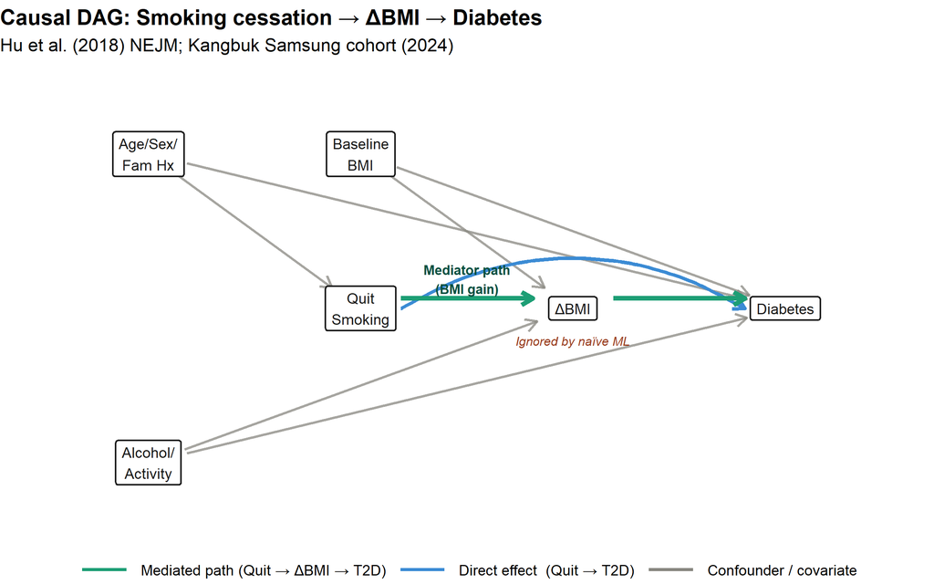

Causal DAG. The mediated path (green) through ΔBMI is what naïve ML ignores when it conditions on post-treatment BMI.

```r
library(ggplot2)

# Node positions
dag_nodes <- data.frame(
  node = c("Quit\nSmoking", "ΔBMI", "Diabetes", "Baseline\nBMI",
           "Age/Sex/\nFam Hx", "Alcohol/\nActivity"),
  x    = c(3, 5, 7, 3, 1, 1),
  y    = c(3, 3, 3, 5, 5, 1)
)

dag_coords <- setNames(dag_nodes[, c("x","y")], c("x","y"))
rownames(dag_coords) <- dag_nodes$node

# Colour palette
pal <- c("mediated" = "#1D9E75",   # green
         "direct"   = "#3B8BD4",   # blue
         "conf"     = "#888780")   # grey

# Helper: nudge start/end away from node centres + optional perpendicular offset
# so parallel edges between the same pair of nodes do not overlap.
nudge <- 0.38
off   <- 0.13   # perpendicular separation

make_edge <- function(fx, fy, tx, ty, type, y_off = 0) {
  dx  <- tx - fx; dy <- ty - fy
  len <- sqrt(dx^2 + dy^2)
  ux  <- dx / len; uy <- dy / len
  # perpendicular unit vector
  px  <- -uy; py <- ux
  data.frame(
    x    = fx + ux * nudge + px * y_off,
    y    = fy + uy * nudge + py * y_off,
    xend = tx - ux * nudge + px * y_off,
    yend = ty - uy * nudge + py * y_off,
    type = type,
    stringsAsFactors = FALSE
  )
}

# Confounder edges (grey) — no parallel overlap with coloured edges
conf_pairs <- list(
  c("Baseline\nBMI",     "ΔBMI"),
  c("Baseline\nBMI",     "Diabetes"),
  c("Age/Sex/\nFam Hx",  "Quit\nSmoking"),
  c("Age/Sex/\nFam Hx",  "Diabetes"),
  c("Alcohol/\nActivity", "ΔBMI"),
  c("Alcohol/\nActivity", "Diabetes")
)
edges_conf <- do.call(rbind, lapply(conf_pairs, function(p)
  make_edge(dag_coords[p[1],"x"], dag_coords[p[1],"y"],
            dag_coords[p[2],"x"], dag_coords[p[2],"y"], "conf", 0)
))

# Mediated path: Quit→ΔBMI and ΔBMI→Diabetes — nudged upward (positive offset)
edges_mediated <- rbind(
  make_edge(dag_coords["Quit\nSmoking","x"], dag_coords["Quit\nSmoking","y"],
            dag_coords["ΔBMI","x"],          dag_coords["ΔBMI","y"],
            "mediated", y_off =  off),
  make_edge(dag_coords["ΔBMI","x"],     dag_coords["ΔBMI","y"],
            dag_coords["Diabetes","x"], dag_coords["Diabetes","y"],
            "mediated", y_off =  off)
)

# Direct effect: Quit→Diabetes as a downward-bowing curve (blue)
# so it is visually separate from the straight green mediated chain
direct_df <- data.frame(
  x    = dag_coords["Quit\nSmoking","x"] + nudge,
  y    = dag_coords["Quit\nSmoking","y"],
  xend = dag_coords["Diabetes","x"] - nudge,
  yend = dag_coords["Diabetes","y"]
)

arr <- arrow(length = unit(0.28, "cm"), type = "open", ends = "last")

ggplot() +
  # 1. confounder edges (grey)
  geom_segment(
    data      = edges_conf,
    aes(x = x, y = y, xend = xend, yend = yend),
    colour    = pal["conf"],
    linewidth = 0.7,
    alpha     = 0.75,
    arrow     = arr
  ) +
  # 2. direct effect (blue curved arc bowing downward)
  geom_curve(
    data      = direct_df,
    aes(x = x, y = y, xend = xend, yend = yend),
    colour    = pal["direct"],
    linewidth = 1.1,
    curvature = -0.30,
    arrow     = arr
  ) +
  # 3. mediated path (green straight segments nudged upward)
  geom_segment(
    data      = edges_mediated,
    aes(x = x, y = y, xend = xend, yend = yend),
    colour    = pal["mediated"],
    linewidth = 1.4,
    arrow     = arr
  ) +
  # Node labels on top of everything
  geom_label(
    data          = dag_nodes,
    aes(x = x, y = y, label = node),
    size          = 3.2,
    fill          = "white",
    colour        = "#1a1a1a",
    label.size    = 0.45,
    label.padding = unit(0.35, "lines")
  ) +
  # Annotation: mediator label above the green arrow
  annotate("text", x = 4, y = 3.38,
           label  = "Mediator path\n(BMI gain)",
           size   = 2.9,
           colour = "#085041",
           fontface = "bold") +
  # Annotation: "ignored by naïve ML" below
  annotate("text", x = 5, y = 2.58,
           label    = "Ignored by naïve ML",
           size     = 2.7,
           colour   = "#993C1D",
           fontface = "italic") +
  # Manual legend using dummy data
  geom_segment(
    data = data.frame(
      x    = c(0,0,0), y    = c(0,0,0),
      xend = c(0,0,0), yend = c(0,0,0),
      type = c("mediated","direct","conf")
    ),
    aes(x=x, y=y, xend=xend, yend=yend, colour=type),
    linewidth = 1
  ) +
  scale_colour_manual(
    values = pal,
    labels = c("mediated" = "Mediated path (Quit → ΔBMI → T2D)",
               "direct"   = "Direct effect  (Quit → T2D)",
               "conf"     = "Confounder / covariate"),
    breaks = c("mediated", "direct", "conf")
  ) +
  labs(
    title    = "Causal DAG: Smoking cessation → ΔBMI → Diabetes",
    subtitle = "Hu et al. (2018) NEJM; Kangbuk Samsung cohort (2024)",
    colour   = NULL, x = NULL, y = NULL
  ) +
  coord_cartesian(xlim = c(0, 8), ylim = c(0.2, 6)) +
  theme_void(base_size = 11) +
  theme(
    plot.title      = element_text(face = "bold"),
    legend.position = "bottom",
    legend.text     = element_text(size = 9),
    legend.key.width = unit(1.2, "cm")
  )
```

## 4 Synthetic cohort

```r
set.seed(2024)
n <- 2000

# Baseline covariates
age      <- round(rnorm(n, 50, 10))
sex      <- rbinom(n, 1, 0.45)          # 1 = male
fam_hx   <- rbinom(n, 1, 0.20)         # family history of T2D
alcohol  <- pmax(0, rnorm(n, 8, 5))    # g/day
activity <- rbinom(n, 1, 0.35)         # physically active

# Baseline BMI — smokers slightly leaner (MR evidence, Atkins 2021)
bmi0 <- 23.5 +
  0.05 * (age - 50) + 1.20 * sex + 0.50 * fam_hx +
  0.04 * alcohol   - 0.80 * activity + rnorm(n, sd = 3.0)
bmi0 <- pmax(16, bmi0)

# Treatment: quit smoking
lp_quit <- -1.2 + 0.015*(age-50) - 0.20*sex + 0.02*(bmi0-23) + 0.30*activity
quit    <- rbinom(n, 1, plogis(lp_quit))

# Mediator: post-cessation BMI change
# Calibrated to Bush (2016): mean gain ≈ +0.9 kg/m² for quitters.
# Interaction coefficient 0.15 (increased from 0.05) to produce a
# detectable CATE gradient across BMI groups: a patient at BMI=30
# gains 0.15*(30-23)=1.05 kg/m² extra vs a patient at BMI=23.
delta_bmi <- 0.90 * quit +
             0.15 * (bmi0 - 23) * quit +   # stronger BMI×quit interaction
             0.30 * (1 - activity) * quit - # sedentary quitters gain more
             0.15 * activity + rnorm(n, sd = 1.2)

bmi_post <- bmi0 + delta_bmi

# Outcome: incident T2D (~5-year risk)
# Calibrated to HR ≈ 1.29 (smokers vs never, Kangbuk Samsung 2024)
# and BMI OR ≈ 1.10 per unit (Hu 2018)
lp_dm <- -5.50 +
  0.035 * (age - 50) + 0.50 * sex + 0.80 * fam_hx +
  0.20  * (bmi_post - 23) + 0.025 * alcohol - 0.40 * activity +
 -0.30  * quit + rnorm(n, sd = 0.3)

diabetes <- rbinom(n, 1, plogis(lp_dm))

cohort <- data.frame(age, sex, fam_hx, alcohol, activity,
                     bmi0, quit, delta_bmi, bmi_post, lp_dm, diabetes)
```

### 4.1 Cohort summary

```r
summary_tbl <- data.frame(
  Statistic = c(
    "Sample size",
    "Quitters, n (%)",
    "T2D cases, n (%)",
    "Mean baseline BMI (SD)",
    "Mean post-treatment BMI (SD)",
    "Mean ΔBMI — quitters",
    "Mean ΔBMI — non-quitters",
    "T2D rate — quitters",
    "T2D rate — non-quitters"
  ),
  Value = c(
    n,
    sprintf("%d (%.1f%%)", sum(quit), 100*mean(quit)),
    sprintf("%d (%.1f%%)", sum(diabetes), 100*mean(diabetes)),
    sprintf("%.2f (%.2f)", mean(bmi0), sd(bmi0)),
    sprintf("%.2f (%.2f)", mean(bmi_post), sd(bmi_post)),
    sprintf("+%.2f kg/m²", mean(delta_bmi[quit==1])),
    sprintf("%.2f kg/m²",  mean(delta_bmi[quit==0])),
    sprintf("%.1f%%", 100*mean(diabetes[quit==1])),
    sprintf("%.1f%%", 100*mean(diabetes[quit==0]))
  )
)
knitr::kable(summary_tbl, col.names = c("Statistic", "Value"),
             caption = "Cohort descriptive statistics")
```

Cohort descriptive statistics

| Statistic | Value |
| --- | --- |
| Sample size | 2000 |
| Quitters, n (%) | 481 (24.1%) |
| T2D cases, n (%) | 38 (1.9%) |
| Mean baseline BMI (SD) | 24.13 (3.20) |
| Mean post-treatment BMI (SD) | 24.40 (3.61) |
| Mean ΔBMI — quitters | +1.20 kg/m² |
| Mean ΔBMI — non-quitters | -0.01 kg/m² |
| T2D rate — quitters | 2.1% |
| T2D rate — non-quitters | 1.8% |

## 5 Analysis A — Naïve ML (incorrect)

Logistic regression predicting T2D from `(quit, bmi_post, covariates)`. This **conditions on `bmi_post`**, a post-treatment variable that lies on the causal path from `quit` to `diabetes`.

```r
naive_fit <- glm(
  diabetes ~ quit + bmi_post + age + sex + fam_hx + alcohol + activity,
  data = cohort, family = binomial
)
naive_coef <- coef(summary(naive_fit))

knitr::kable(
  data.frame(
    Term    = rownames(naive_coef),
    Estimate = round(naive_coef[,"Estimate"], 4),
    OR       = round(exp(naive_coef[,"Estimate"]), 3),
    `p-value` = round(naive_coef[,"Pr(>|z|)"], 4)
  ),
  caption = "Naïve ML: logistic regression coefficients (biased)"
)
```

Naïve ML: logistic regression coefficients (biased)

|  | Term | Estimate | OR | p.value |
| --- | --- | --- | --- | --- |
| (Intercept) | (Intercept) | -16.2464 | 0.000 | 0.0000 |
| quit | quit | -0.5456 | 0.579 | 0.1871 |
| bmi_post | bmi_post | 0.3752 | 1.455 | 0.0000 |
| age | age | 0.0339 | 1.034 | 0.0578 |
| sex | sex | 0.1562 | 1.169 | 0.6586 |
| fam_hx | fam_hx | 1.3318 | 3.788 | 0.0001 |
| alcohol | alcohol | 0.0333 | 1.034 | 0.3569 |
| activity | activity | -0.8184 | 0.441 | 0.0812 |

**Why this is wrong — and what “underestimate” really means here**

`bmi_post` is a **mediator**, not a baseline covariate. Including it in the outcome model as if it were fixed — independently of `quit` — blocks the `quit → ΔBMI → T2D` path.

To see the direction of the bias, recall that the outcome is **diabetes risk** (higher = worse) and the `quit` coefficient is negative (protective). By holding BMI fixed while varying `quit`, naïve ML asks: *“What is the effect of quitting if BMI does not change?”* This removes the harmful BMI-gain pathway, making quitting appear **more protective than it really is**. In other words:

- Naïve ML **overestimates the protective benefit** of quitting (OR for `quit` is too far below 1.0).
- As a consequence, it **underestimates the true diabetes risk** a quitter faces in the real world, where BMI *does* rise after cessation and partially offsets the direct benefit.
- The causal analyses (B and C) recover a smaller protective effect — i.e. an ATE closer to zero — because they correctly propagate `do(quit=1) → ΔBMI ↑ → T2D risk ↑`, which partially cancels the direct protective path. This is precisely the short-term dynamic documented by Hu et al. (2018): the transient T2D spike after cessation is driven by weight gain.

## 6 Interpreting effect sizes: log-odds vs probability scale

The SEM encodes the direct effect of quitting as $-0.30$ on the **log-odds scale**. The causal analyses (B and C) report results on the **risk difference (probability) scale**. These are not directly comparable, and the conversion is non-linear. This section derives the expected probability-scale values from the SEM parameters.

### 6.1 The delta method approximation

The probability of T2D is linked to the log-odds linear predictor $\eta$ by the logistic function:

$$P(\text{T2D}) = \sigma(\eta) = \frac{1}{1 + e^{-\eta}}$$

When `quit` changes from 0 to 1, the linear predictor changes by $\Delta\eta = -0.30$. The resulting change in probability — the risk difference — is found by differentiating $\sigma(\eta)$:

$$\frac{d\sigma}{d\eta} = \sigma(\eta)\,(1 - \sigma(\eta)) = P\,(1-P)$$

This is the **variance of a Bernoulli random variable** at baseline probability $P$. Applying the delta method:

$$\Delta P \approx P(1-P)\cdot\Delta\eta
= 0.05 \times 0.95 \times 0.30 \approx 0.014$$

The $P(1-P)$ term controls how sensitive the probability scale is to log-odds changes. It is maximised at $P=0.5$ (equals $0.25$) and shrinks toward zero as the outcome becomes rare or very common:

| Baseline prevalence $P$ | $P(1-P)$ | Risk difference for $\|\Delta\eta\|=0.30$ |
| --- | --- | --- |
| 0.05 (5%) | 0.0475 | $\approx 0.014$ |
| 0.10 (10%) | 0.0900 | $\approx 0.027$ |
| 0.30 (30%) | 0.2100 | $\approx 0.063$ |
| 0.50 (50%) | 0.2500 | $\approx 0.075$ |

### 6.2 Approximation error

The delta method linearises the logistic curve. For $\Delta\eta = -0.30$ the exact calculation is:

$$\eta_0 = \log\!\left(\frac{0.05}{0.95}\right) \approx -2.944$$

$$P(\text{quit}=0) = \sigma(-2.944) = 0.050$$

$$P(\text{quit}=1) = \sigma(-2.944 - 0.30) = \sigma(-3.244) \approx 0.0377$$

$$\Delta P_{\text{exact}} = 0.0377 - 0.050 = -0.0123$$

Versus the delta method approximation of $-0.014$. The error of $\approx 0.002$ arises because the logistic curve is concave at $P=0.05$ — the linear approximation overshoots. The mediation package and g-formula evaluate the logistic function exactly through simulation and prediction, so they will be closer to $-0.012$ than $-0.014$.

### 6.3 What to expect from Analyses B and C

Combining the direct effect ($-0.30$ log-odds) with the opposing mediated pathway — quitting raises BMI by $+0.90$ kg/m$^2$ on average, and each kg/m$^2$ increases log-odds of T2D by $+0.20$, contributing $+0.90 \times 0.20 = +0.18$ log-odds — gives a net log-odds change of $-0.30 + 0.18 = -0.12$. Converting to the probability scale:

$$\Delta P_{\text{net}} \approx 0.05 \times 0.95 \times 0.12 \approx 0.006$$

The subsection below explains why the ADE is expressed as a range, then provides the full expected-value table.

### 6.4 Why the ADE has a range rather than a single expected value

The ADE expected value is given as a range ($-0.010$ to $-0.014$) rather than a single number because there are **two legitimate but different approximation paths** to the same underlying quantity, and they give slightly different answers.

**Path 1 — Delta method (linear approximation):** applies the first-order Taylor expansion of the logistic function at the baseline probability $P = 0.05$:

$$\text{ADE}_{\text{delta}} \approx -P(1-P) \times |\Delta\eta|
= -0.05 \times 0.95 \times 0.30 = -0.01425 \approx -0.014$$

This uses the derivative $d\sigma/d\eta = P(1-P)$ evaluated at the baseline log-odds $\eta_0$, and treats the logistic curve as locally linear. It is an *upper bound* on the magnitude because the logistic curve is concave at $P = 0.05$ — the linear approximation overshoots.

**Path 2 — Exact calculation:** evaluates the logistic function directly at the baseline log-odds and at the shifted value:

$$\eta_0 = \log\!\left(\frac{0.05}{0.95}\right) \approx -2.944$$

$$\text{ADE}_{\text{exact}} = \sigma(\eta_0 - 0.30) - \sigma(\eta_0)
= \sigma(-3.244) - \sigma(-2.944) \approx 0.0377 - 0.0500 = -0.0123$$

This is the true value of the ADE implied by the SEM, without approximation. The mediation package and g-formula use this exact evaluation (through simulation and prediction from the fitted logistic model), so the ADE they report should be close to $-0.012$, not $-0.014$.

**Why a range rather than the single exact value $-0.012$?** The range brackets both estimates to make clear that:

1. The delta method ($-0.014$) and the exact value ($-0.012$) are both legitimate derivations of the same quantity — they differ only due to the approximation error of $\approx 0.002$.
2. The simulated ATE from the data will not be exactly $-0.012$ either, because the cohort has additional sources of variability (residual noise $\varepsilon_3 \sim \mathcal{N}(0, 0.3^2)$ in $\text{lp\_dm}$, finite sample variation, subgroup heterogeneity) that shift the realised baseline prevalence slightly from $5\%$, which in turn shifts the $P(1-P)$ scaling factor.

The range $-0.010$ to $-0.014$ is therefore a **prediction interval** for what the analysis will return, not an expression of uncertainty about a fixed quantity. In practice any value in this range confirms the SEM parameters are being correctly recovered.

| Quantity | Scale | Derivation | Expected value |
| --- | --- | --- | --- |
| Direct effect of quit | Log-odds | SEM coefficient | $-0.30$ (exact) |
| ADE (direct effect) | Risk difference | Delta method | $-0.014$ (upper bound) |
| ADE (direct effect) | Risk difference | Exact logistic | $-0.012$ (best single value) |
| ADE prediction interval | Risk difference | Both paths + noise | $-0.010$ to $-0.014$ |
| Mediated effect via BMI | Risk difference | $P(1-P) \times 0.18$ | $\approx +0.005$ to $+0.008$ |
| ATE (total effect) | Risk difference | ADE + ACME | $\approx -0.004$ to $-0.008$ |
| OR for quit (direct) | Odds ratio | $e^{-0.30}$ | $\approx 0.74$ (exact) |
| OR for $\Delta$BMI per kg/m$^2$ | Odds ratio | $e^{+0.20}$ | $\approx 1.22$ (exact) |

**Key takeaways on scale and the ADE range**

The ADE of $\approx -0.012$ is **not** a discrepancy from the SEM’s $-0.30$ — they are the same direct effect on different scales. Comparing $-0.012$ (risk difference) with $-0.30$ (log-odds) directly is a category error. The OR of $e^{-0.30} \approx 0.74$ is the correct log-odds-scale equivalent of the ADE.

The range $-0.010$ to $-0.014$ in the table above reflects two legitimate approximation paths (delta method vs exact logistic evaluation) plus finite-sample variability. The single best analytical prediction is $-0.012$ from the exact calculation. Values returned by Analyses B and C should fall within this range.

## 7 Analysis B — Causal mediation analysis

### 7.1 Statistical framework

The `mediation` package (Imai, Keele, and Tingley 2010) implements the **potential outcomes** decomposition of the total effect. Define $Y_i(t, m)$ as the potential outcome for individual $i$ under treatment $T = t$ and mediator value $M = m$. The package estimates three quantities:

$$\text{ACME}(t) = E\bigl[Y_i(t,\, M_i(1)) - Y_i(t,\, M_i(0))\bigr]$$

$$\text{ADE}(t) = E\bigl[Y_i(1,\, M_i(t)) - Y_i(0,\, M_i(t))\bigr]$$

$$\text{TE} = E\bigl[Y_i(1,\, M_i(1)) - Y_i(0,\, M_i(0))\bigr] = \text{ACME}(t) + \text{ADE}(t)$$

where $M_i(t)$ is the **potential mediator value** individual $i$ would have under treatment $t$. The ACME (Average Causal Mediation Effect) captures the path **Quit $\rightarrow$ $\Delta$BMI $\rightarrow$ T2D**; the ADE (Average Direct Effect) captures the path **Quit $\rightarrow$ T2D**, holding the mediator fixed at the value it would take under one treatment arm.

### 7.2 Implementation: two-model approach

The package requires two fitted models:

**Step 1 — Mediator model** (linear, since $\Delta$BMI is continuous):

$$\Delta\text{BMI}_i = \alpha_0 + \alpha_1\,\text{Quit}_i
+ \alpha_2\,\text{BMI}_{0i} + \boldsymbol{\alpha}_c^\top \mathbf{C}_i + \varepsilon_i^M,
\quad \varepsilon_i^M \sim \mathcal{N}(0,\sigma_M^2)$$

where $\mathbf{C}_i = (\text{Age}_i, \text{Sex}_i, \text{FamHx}_i, \text{Alcohol}_i, \text{Activity}_i)^\top$ are pre-treatment confounders. The key coefficient is $\hat\alpha_1$: the average BMI gain caused by quitting, holding confounders fixed.

**Step 2 — Outcome model** (logistic, since T2D is binary):

$$\text{logit}\,P(\text{T2D}_i = 1) = \beta_0 + \beta_1\,\text{Quit}_i
+ \beta_2\,\Delta\text{BMI}_i + \boldsymbol{\beta}_c^\top \mathbf{C}_i + \varepsilon_i^Y$$

Here $\beta_1$ is the **direct effect** of quitting (log-odds scale) and $\beta_2$ is the effect of BMI gain on T2D risk.

**Step 3 — Simulation** (`sims = 500`): for each bootstrap draw the package:

1. Draws $\hat M_i(0)$ and $\hat M_i(1)$ from the mediator model posterior
2. Plugs both into the outcome model under each treatment assignment
3. Averages the contrasts to obtain ACME and ADE on the **probability scale**

This simulation-based approach correctly handles the non-linearity of the logistic outcome model — it does not assume effects add linearly on the probability scale.

```r
# Mediator model: ΔBMI ~ quit + confounders
med_model <- lm(
  delta_bmi ~ quit + bmi0 + age + sex + fam_hx + alcohol + activity,
  data = cohort
)

# Outcome model: T2D ~ quit + ΔBMI + confounders
out_model <- glm(
  diabetes ~ quit + delta_bmi + bmi0 + age + sex + fam_hx + alcohol + activity,
  data = cohort, family = binomial
)

med_out <- mediate(
  med_model, out_model,
  treat    = "quit",
  mediator = "delta_bmi",
  robustSE = TRUE,
  sims     = 500
)
```

```r
# Outcome model log-odds coefficients for OR conversion
out_coef <- coef(out_model)

med_tbl <- data.frame(
  Component = c("ACME (BMI-mediated effect)", "ADE (direct effect of quit)",
                "Total effect (ATE)", "Proportion mediated via BMI"),
  `Risk difference` = round(
    c(med_out$d0, med_out$z0, med_out$tau.coef, med_out$n0), 4),
  `95% CI` = c(
    sprintf("[%.4f, %.4f]", med_out$d0.ci[1],  med_out$d0.ci[2]),
    sprintf("[%.4f, %.4f]", med_out$z0.ci[1],  med_out$z0.ci[2]),
    sprintf("[%.4f, %.4f]", med_out$tau.ci[1], med_out$tau.ci[2]),
    "—"),
  `Note` = c(
    "Harmful offsetting path: BMI gain raises T2D risk",
    sprintf("OR = %.3f from outcome model log-odds = %.3f",
            exp(out_coef["quit"]), out_coef["quit"]),
    "Net effect on probability scale (ADE + ACME)",
    "Fraction of total effect operating via BMI"),
  check.names = FALSE
)
knitr::kable(med_tbl, digits = 4,
             caption = paste0(
               "Causal mediation decomposition (Imai et al. 2010). ",
               "Risk differences are on the probability scale. ",
               "The OR for the direct effect is extracted from the ",
               "outcome model log-odds coefficient for quit."))
```

Causal mediation decomposition (Imai et al. 2010). Risk differences are on the probability scale. The OR for the direct effect is extracted from the outcome model log-odds coefficient for quit.

| Component | Risk difference | 95% CI | Note |
| --- | --- | --- | --- |
| ACME (BMI-mediated effect) | 0.0113 | [0.0036, 0.0237] | Harmful offsetting path: BMI gain raises T2D risk |
| ADE (direct effect of quit) | -0.0084 | [-0.0198, 0.0038] | OR = 0.544 from outcome model log-odds = -0.608 |
| Total effect (ATE) | -0.0016 | [-0.0146, 0.0139] | Net effect on probability scale (ADE + ACME) |
| Proportion mediated via BMI | -1.1480 | — | Fraction of total effect operating via BMI |

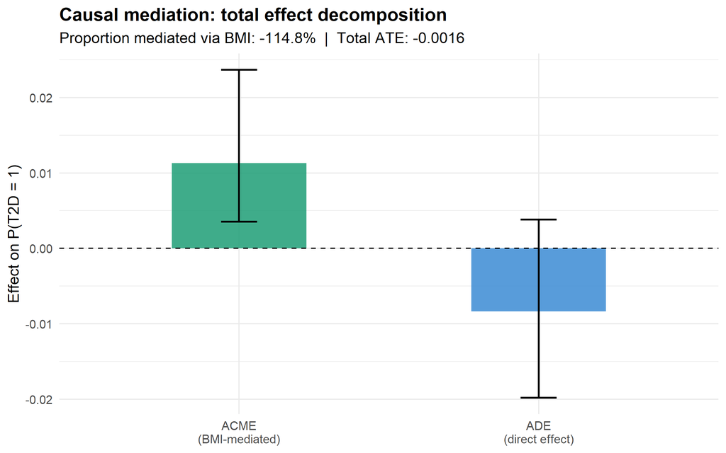

```r
med_bar <- data.frame(
  component = factor(c("ACME\n(BMI-mediated)", "ADE\n(direct effect)"),
                     levels = c("ACME\n(BMI-mediated)", "ADE\n(direct effect)")),
  estimate  = c(med_out$d0, med_out$z0),
  lo        = c(med_out$d0.ci[1], med_out$z0.ci[1]),
  hi        = c(med_out$d0.ci[2], med_out$z0.ci[2])
)

ggplot(med_bar, aes(x = component, y = estimate, fill = component)) +
  geom_col(width = 0.45, alpha = 0.85) +
  geom_errorbar(aes(ymin = lo, ymax = hi), width = 0.12, linewidth = 0.7) +
  geom_hline(yintercept = 0, linetype = "dashed", linewidth = 0.5) +
  scale_fill_manual(values = c("#1D9E75", "#3B8BD4")) +
  labs(
    title    = "Causal mediation: total effect decomposition",
    subtitle = sprintf("Proportion mediated via BMI: %.1f%%  |  Total ATE: %.4f",
                       med_out$n0 * 100, med_out$tau.coef),
    x = NULL, y = "Effect on P(T2D = 1)", fill = NULL
  ) +
  theme_minimal(base_size = 12) +
  theme(plot.title = element_text(face = "bold"), legend.position = "none")
```

## 8 Analysis C — G-formula (parametric SCM)

### 8.1 Statistical framework

The **g-formula** (or parametric g-computation) implements Pearl’s do-calculus directly. It computes $E[Y(\text{do}(T=t))]$ — the mean outcome under a hypothetical intervention that sets treatment to $t$ for everyone — rather than the conditional expectation $E[Y \mid T=t]$ which conflates causal and selection effects.

The key insight is the **g-computation identity** for a mediator $M$ and confounders $\mathbf{C}$:

$$E[Y(\text{do}(T=t))] =
\int_{\mathbf{c}} \int_m
E[Y \mid T=t,\, M=m,\, \mathbf{C}=\mathbf{c}]\;
\underbrace{p(m \mid T=t,\, \mathbf{C}=\mathbf{c})}_{\text{mediator dist. under } do(T=t)}\;
p(\mathbf{c})\; dm\, d\mathbf{c}$$

The crucial difference from naïve ML is the distribution over $M$: naïve ML conditions on the **observed** $M_i$ (which was realised under the individual’s actual treatment); the g-formula integrates over the **predicted** $M$ under the intervention value $t$. This correctly propagates $\text{do}(\text{Quit}=1) \rightarrow \Delta\text{BMI} \uparrow \rightarrow \text{T2D risk} \uparrow$.

### 8.2 Implementation: three-step algorithm

**Step 1 — Fit the mediator model** on observed data:

$$\widehat{\Delta\text{BMI}}_i^{(t)} =
\hat\alpha_0 + \hat\alpha_1\,t
+ \hat\alpha_2\,\text{BMI}_{0i}
+ \hat{\boldsymbol{\alpha}}_c^\top \mathbf{C}_i$$

For each individual, predict $\Delta$BMI *as if* $\text{Quit} = t$, regardless of their observed treatment. This is the operationalisation of $\text{do}(\text{Quit} = t)$ in the mediator equation.

**Step 2 — Predict T2D risk using the counterfactual mediator**:

$$\hat P_i^{(t)} = \sigma\!\left(
\hat\beta_0 + \hat\beta_1\,t
+ \hat\beta_2\,\widehat{\Delta\text{BMI}}_i^{(t)}
+ \hat{\boldsymbol{\beta}}_c^\top \mathbf{C}_i\right)$$

**Step 3 — Average over the covariate distribution** (standardisation):

$$\widehat{\text{ATE}} =
\frac{1}{n}\sum_{i=1}^n \hat P_i^{(1)}
- \frac{1}{n}\sum_{i=1}^n \hat P_i^{(0)}$$

This is a **Monte Carlo approximation** of the population-level do-calculus integral, using the observed covariate distribution as the reference population. The bootstrap CI re-runs all three steps on each resample to propagate uncertainty from both models.

**Why this differs from naïve ML:** Naïve ML predicts $E[\text{T2D} \mid \text{Quit}=1, \Delta\text{BMI} = \Delta\text{BMI}_i^{\text{obs}}]$ — it plugs in the *observed* BMI change for each individual, which was determined under their actual (not counterfactual) treatment. A quitter who happened to gain little weight gets a low predicted risk; a hypothetical non-quitter who would have gained weight anyway is never considered. The g-formula instead asks: *if this individual were assigned to quit, what BMI change would we predict, and what T2D risk would follow?*

```r
med_gform <- lm(
  delta_bmi ~ quit + bmi0 + age + sex + fam_hx + alcohol + activity,
  data = cohort
)
out_gform <- glm(
  diabetes ~ quit + delta_bmi + bmi0 + age + sex + fam_hx + alcohol + activity,
  data = cohort, family = binomial
)

gformula_ate <- function(df, treat_val) {
  df_int           <- df
  df_int$quit      <- treat_val
  df_int$delta_bmi <- predict(med_gform, newdata = df_int)
  mean(predict(out_gform, newdata = df_int, type = "response"))
}

p_dm_quit  <- gformula_ate(cohort, 1)
p_dm_smoke <- gformula_ate(cohort, 0)
ate_gform  <- p_dm_quit - p_dm_smoke

# Bootstrap 95% CI
set.seed(42)
boot_ate <- replicate(500, {
  idx <- sample(nrow(cohort), replace = TRUE)
  b   <- cohort[idx, ]
  m   <- lm(delta_bmi ~ quit + bmi0 + age + sex + fam_hx + alcohol + activity, data = b)
  o   <- glm(diabetes  ~ quit + delta_bmi + bmi0 + age + sex + fam_hx + alcohol + activity,
             data = b, family = binomial)
  f   <- function(tv) {
    d <- b; d$quit <- tv; d$delta_bmi <- predict(m, newdata = d)
    mean(predict(o, newdata = d, type = "response"))
  }
  f(1) - f(0)
})
ci_gform <- quantile(boot_ate, c(0.025, 0.975))
```

```r
# OR approximation from the outcome model used in the g-formula
out_gform_coef <- coef(out_gform)
or_direct_gform <- exp(out_gform_coef["quit"])
or_bmi_gform    <- exp(out_gform_coef["delta_bmi"])

# Risk ratio approximation: P(T2D|do(quit=1)) / P(T2D|do(quit=0))
rr_gform <- p_dm_quit / p_dm_smoke

gform_tbl <- data.frame(
  Quantity = c(
    "P(T2D = 1 | do(quit=1))",
    "P(T2D = 1 | do(quit=0))",
    "ATE  [do(quit=1) − do(quit=0)]",
    "95% bootstrap CI",
    "Risk ratio  [do(quit=1) / do(quit=0)]",
    "OR for quit (log-odds, outcome model)",
    "OR for ΔBMI per 1 kg/m² (outcome model)"
  ),
  Value = c(
    sprintf("%.4f", p_dm_quit),
    sprintf("%.4f", p_dm_smoke),
    sprintf("%.4f", ate_gform),
    sprintf("[%.4f, %.4f]", ci_gform[1], ci_gform[2]),
    sprintf("%.3f", rr_gform),
    sprintf("%.3f  (log-odds = %.3f)", or_direct_gform, out_gform_coef["quit"]),
    sprintf("%.3f  (log-odds = %.3f)", or_bmi_gform,    out_gform_coef["delta_bmi"])
  ),
  Interpretation = c(
    "Predicted T2D probability if everyone quits (BMI allowed to rise)",
    "Predicted T2D probability if no one quits",
    "Causal risk difference — net effect on probability scale",
    "Bootstrap percentile interval for ATE",
    "Relative risk — quitters vs non-quitters under do-calculus",
    "Direct protective effect of quitting; OR < 1 = protective",
    "Harmful effect of each kg/m² BMI gain; OR > 1 = harmful"
  )
)
knitr::kable(gform_tbl,
  caption = paste0(
    "G-formula results. The ATE is on the probability (risk difference) scale. ",
    "ORs are from the outcome model and are on the log-odds scale — ",
    "they cannot be directly compared to the ATE but show the direction and ",
    "magnitude of each pathway before the offsetting effects are combined."))
```

G-formula results. The ATE is on the probability (risk difference) scale. ORs are from the outcome model and are on the log-odds scale — they cannot be directly compared to the ATE but show the direction and magnitude of each pathway before the offsetting effects are combined.

| Quantity | Value | Interpretation |
| --- | --- | --- |
| P(T2D = 1 \| do(quit=1)) | 0.0159 | Predicted T2D probability if everyone quits (BMI allowed to rise) |
| P(T2D = 1 \| do(quit=0)) | 0.0175 | Predicted T2D probability if no one quits |
| ATE [do(quit=1) − do(quit=0)] | -0.0016 | Causal risk difference — net effect on probability scale |
| 95% bootstrap CI | [-0.0117, 0.0133] | Bootstrap percentile interval for ATE |
| Risk ratio [do(quit=1) / do(quit=0)] | 0.910 | Relative risk — quitters vs non-quitters under do-calculus |
| OR for quit (log-odds, outcome model) | 0.544 (log-odds = -0.608) | Direct protective effect of quitting; OR < 1 = protective |
| OR for ΔBMI per 1 kg/m² (outcome model) | 1.515 (log-odds = 0.416) | Harmful effect of each kg/m² BMI gain; OR > 1 = harmful |